# A7 - Series de Tiempo

Esteban Sierra

2025-11-18

# Sección 1: Preparación

```r
# Cargar las librerías necesarias
library(forecast)
```

```r
library(ggplot2)
```

```r
# Insertar datos
anio = c(1,1,1,1,2,2,2,2,3,3,3,3,4,4,4,4)
trimestre = c(1,2,3,4,1,2,3,4,1,2,3,4,1,2,3,4)
ventas = c(4.8, 4.1, 6.0, 6.5, 5.8, 5.2, 6.8, 7.4, 6.0, 5.6, 7.5, 7.8, 6.3, 5.9, 8.0, 8.4)

x = ts(ventas, frequency = 4, start = c(2016, 1))

Datos = data.frame(anio,trimestre,ventas)

serie_de_tiempo_ventas <- ts(
    data = Datos$ventas,
    start = c(Datos$anio[1], Datos$trimestre[1]),
    frequency = 4
)

print(serie_de_tiempo_ventas)
```

```
##   Qtr1 Qtr2 Qtr3 Qtr4
## 1  4.8  4.1  6.0  6.5
## 2  5.8  5.2  6.8  7.4
## 3  6.0  5.6  7.5  7.8
## 4  6.3  5.9  8.0  8.4
```

Graficar

```r
library(ggfortify)
```

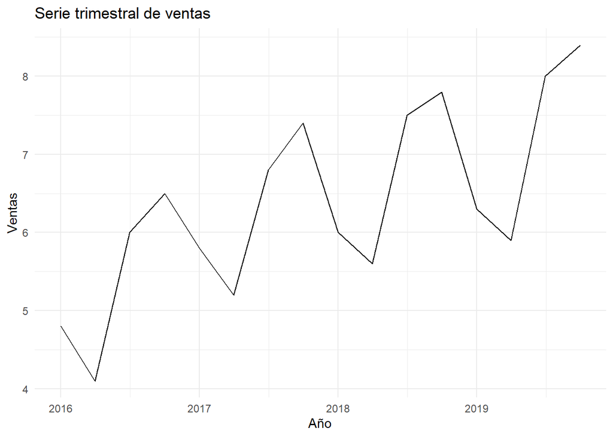

```r
library(ggplot2)

autoplot(x) +
  ggtitle("Serie trimestral de ventas") +
  xlab("Año") + ylab("Ventas") +
  theme_minimal()
```

Con mis palabras puramente y únicamente mías puedo mencionar que en este gráfico se logra ver cómo si existe algún tipo de estacionalidad a través de los años.

# Sección 2: Ajuste automático del modelo ARIMA

```r
modelo = auto.arima(x)
modelo
```

```
## Series: x
## ARIMA(0,1,0)(0,1,0)[4]
##
## sigma^2 = 0.08001:  log likelihood = -1.72
## AIC=5.43   AICc=5.88   BIC=5.83
```

$$ARIMA(p,d,q)(P,D,Q)[s]$$
Tomando en cuenta que es un modelo estacional, sabemos que:

# Sección 3: Pronóstico del siguiente año

```r
pred = forecast(modelo, h = 4, level = 95)
pred
```

```
##         Point Forecast    Lo 95     Hi 95
## 2020 Q1            6.9 6.345607  7.454393
## 2020 Q2            6.5 5.715970  7.284030
## 2020 Q3            8.6 7.639763  9.560237
## 2020 Q4            9.0 7.891214 10.108786
```

**Escribe los 4 valores pronosticados, ¿son diferentes a los valores pronosticados con tu modelo “a mano” de la clase pasada?** Los valores pronosticados son 6.9, 6.5, 8.6, y 9.0. Contra los valores anteriores: 6.7, 6.1, 8.0, y 8.4. Los valores son diferentes, sin embargo, ambos siguen la misma tendencia al aumentar dependiendo del cuatrimestre.

**¿Qué representan las columnas Lo95 y Hi95?** Lo95 representa el valor mínimo que tendrá para tener un 95% de confianza. Hi95 representa el valor máximo que tendrá manteniendo un 95% de confianza. Esto significa, que tomando en cuenta los límites,los valores obtenidos por el pronostico realizado a mano entran dentro del rango y podrían ser correctos.

# Serie + Ajuste + Pronóstico + IC 95%

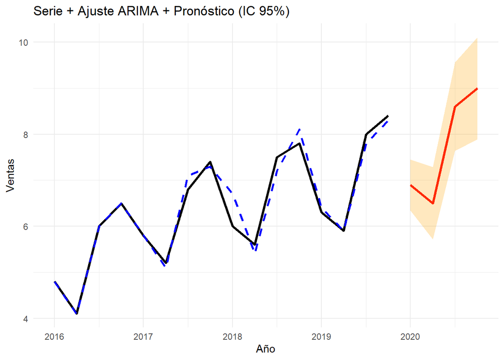

```r
#Grafica la serie más su pronóstico más su intervalo de confianza:
ajuste = fitted(modelo)

df = data.frame(tiempo = as.numeric(time(x)), ventas = as.numeric(x), ajuste = as.numeric(ajuste))
df_pred = data.frame(tiempo = as.numeric(time(pred$mean)), pred= as.numeric(pred$mean), lo95   = as.numeric(pred$lower[ , "95%"]), hi95   = as.numeric(pred$upper[ , "95%"]))
ggplot() +
  geom_line(data = df, aes(x = tiempo, y = ventas), color = "black", size = 1.1) +
  geom_line(data = df, aes(x = tiempo, y = ajuste), color = "blue", linetype = "dashed", size = 1) +
  geom_line(data = df_pred, aes(x = tiempo, y = pred), color = "red", size = 1.2) +
  geom_ribbon(data = df_pred, aes(x = tiempo, ymin = lo95, ymax = hi95), fill = "orange", alpha = 0.25) +
  labs(title = "Serie + Ajuste ARIMA + Pronóstico (IC 95%)",  x = "Año", y = "Ventas") +
  theme_minimal()
```

**¿El ajuste ARIMA sigue bien los datos históricos?** Si. Podemos ver que el ajuste de ARIMA tiene sentido tomando en cuenta los datos históricos.

**¿El pronóstico reproduce la estacionalidad que observaste en la serie original?** La serie original mantiene valores más bajos. Sin embargo se encontraban también dentor del rango, por lo que si lo repreoduce.

**¿La banda de confianza crece o permanece estable? ¿Qué significa eso?** La banda de confianza crece, esto sucede ya que entre más tiempo pase, hay más factores que pueden influir y se multiplica.

# Sección 5: Métricas de evaluación

```r
accuracy(modelo)
```

```
##                       ME      RMSE       MAE       MPE     MAPE      MASE
## Training set -0.02523102 0.2345341 0.1509357 -0.439108 2.269994 0.2515595
##                    ACF1
## Training set -0.3038761
```

**¿Qué valor tiene el RMSE? ¿Es grande o pequeño en relación con la escala de la serie?** El RMSE tiene un valor de 0.2345341. Tomando en cuenta que los valores se encuentran en *miles de ventas*, podemos decir que el valor es bajo ya que representaría menos del 4% de las ventas totales.

**¿Qué métrica usarías para explicar el error a un gerente no técnico?** Le diría que existe una alta posibilidad de error del 4%, de esta forma el gerente entenderá que es posible que se desvíe únicamente en un 4%.

# Sección 6: Diagnóstico de residuos

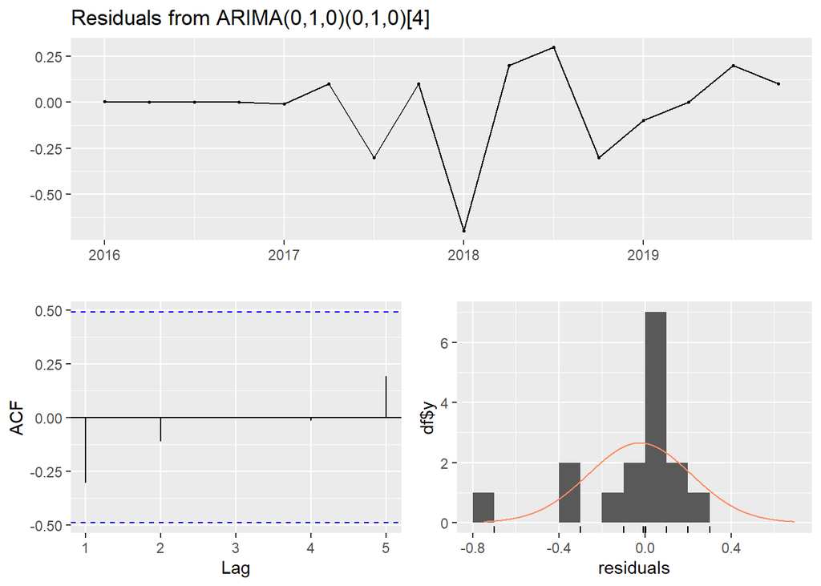

```
##
##  Ljung-Box test
##
## data:  Residuals from ARIMA(0,1,0)(0,1,0)[4]
## Q* = 2.0251, df = 3, p-value = 0.5672
##
## Model df: 0.   Total lags used: 3
```

```r
checkresiduals(modelo)
```

*Residuos vs tiempo: ¿Los residuos parecen ruido blanco? Es decir, ¿se ven sin tendencia?, ¿sin estacionalidad?, ¿sin grandes picos aislados?* Al ver la gráfica de los residuos a través del tiempo podemos verificar que estos no tienen alguna tendencia ni estacionalidad. Sin embargo existe un pico aislado hacia abajo en el año 2018. Esto probablemente se deba a que ese año existió una diferencia significativa entre la predicción y lo obtenido realmente.

**Histograma: ¿Los residuos son aproximadamente simétricos?** No. Los residuos no son simétricos. Esto lo podemos ver en el histograma y los picos de este.

**ACF: ¿Algún lag sobresale más allá de las bandas azules? ¿Qué significa eso?** No. Ningún lag sobresale más allá de las bandas azules. Eso significa que no existe ningúna autorelación significativa. Esto significa que el modelo obtenido es ideal para nuestro sistema.

**Prueba Ljung–Box. En esta prueba: H0: los residuos son ruido blanco (no hay autocorrelación). Indica con un nivel de significancia de 0.03 si el modelo explica toda la estructura.**

```r
Box.test(x, lag = 1, type = "Ljung-Box", fitdf = 0)
```

```
##
##  Box-Ljung test
##
## data:  x
## X-squared = 2.6048, df = 1, p-value = 0.1065
```

# Sección 7: Verificación de los supuestos

```r
library(lmtest)
dwtest(residuals(modelo) ~ 1)
```

```
##
##  Durbin-Watson test
##
## data:  residuals(modelo) ~ 1
## DW = 2.5888, p-value = 0.8909
## alternative hypothesis: true autocorrelation is greater than 0
```

**Con un nivel de significancia de 0.03 indica si los residuos son ruido blanco** Si. Los residuos son ruido blanco.

## Prueba formal de normalidad de los residuos

```r
# Prueba de hipotesis
shapiro.test(residuals(modelo))
```

```
##
##  Shapiro-Wilk normality test
##
## data:  residuals(modelo)
## W = 0.85198, p-value = 0.01457
```

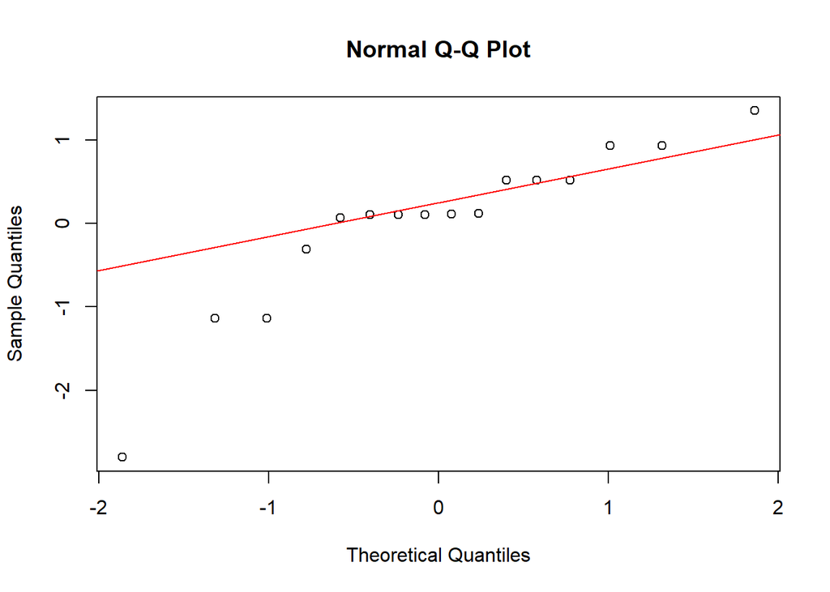

```r
# Grafica de QQplot de los residuos estandarizados:
qqnorm(scale(residuals(modelo)))
qqline(scale(residuals(modelo)), col = "red")
```

## Prueba de heterocedasticidad (Breusch–Pagan).

```r
bptest(residuals(modelo) ~ time(x))
```

```
##
##  studentized Breusch-Pagan test
##
## data:  residuals(modelo) ~ time(x)
## BP = 0.23434, df = 1, p-value = 0.6283
```

**Con un nivel de significancia de 0.03, interpreta que tan razonable es el ARIMA obtenido** Tomando en cuenta que p-value (0.6283) es mucho mayor al nivel de significancia (0.03), no tenemos evidencia para rechazar la hipótesis nula (H0). Lo que significa que el modeo es razonáblemente válido.

## Identificación de outliers y puntos de influencia.

```r
res = scale(residuals(modelo))
which(abs(res) > 2*sd(res))
```

```
## [1] 9
```

**Identifica trimestres donde el residuo es demasiado grande, puede indicar cambios estructurales o mala captura de algún patrón estacional o tendencia local.** El trimestre donde el residuo es demasiadogrande es el #9.

# Sección 8: Conclusión

## Identificación del modelo

**Qué ARIMA/SARIMA encontraste (escribe su forma).** El ARIMA encontrado va subiendo en base a cuatro intérvalos, uno el segundo baja un poco, el tercero sube mucho y el cuarto sube aún más.

## Comportamiento del pronóstico.

La banda de confianza si es razonable, esta va creciendo a medida que se aleja el pronóstico, esto se debe a que se tienen menos datos para poder pronosticarlo y dependería de otros factores. Sin embargo, el patrón estacional es muy claro y muy marcado en cuanto a la diferencia un cuatrimestre con otro.

## Qué indican los residuos

Los residuos indican que tánto falló el modelo al momento de pronosticar los datos reales. Si tenemos munchos residuos es que fallo mucho, y se puede investigar el por qué, si tenemos pocos residuos entonces podemos decir que el modelo funciona lo suficientemente.

## Juicio final sobre la utilidad del modelo.

**¿Los pronósticos son confiables para toma de decisiones?** Si. Podemos decir que los pronósticos son confiables.

**¿O habría que intentar un modelo más complejo?** No es necesario intentar un modelo más complejo, ya que este tiene todo lo necesario.